# Cluster Analysis

Deviprasad Saka

2024-03-07

```r
library(MASS)
library(factoextra)
```

```r
library(ggplot2)
library(readxl)
library(factoextra)
library(ggfortify)
library(ggrepel)
library(stats)

# Define the file path
file_path <- "D:/Multivariate Analysis/Datasets/Body Measurements _ original_CSV.csv"
# Read the CSV file
body <- read.csv(file_path)
# Standardized the data set excluding the first variable which is categorical
data.scaled <- scale(x = body[, -1], center = TRUE, scale = TRUE)
data <- data.scaled
head(data)
```

```
##            Age HeadCircumference ShoulderWidth ChestWidth      Belly
## [1,] 1.2389990         0.3809359    0.77337695  1.0217364 -0.2170850
## [2,] 1.0699588        -0.4204846    1.61332824  0.4572586 -0.2170850
## [3,] 0.9854386         0.1137957    0.77337695  0.2690993 -0.6118351
## [4,] 1.1544789        -0.1533444    1.19335259  0.6454178 -0.9078977
## [5,] 1.0699588        -1.2219050   -0.06657435  0.6454178 -0.7105226
## [6,] 0.5628380        -0.9547649    0.98336477  0.6454178 -0.6118351
##            Waist       Hips ArmLength ShoulderToWaist WaistToKnee  LegLength
## [1,] -0.60033514  0.2997646 0.5920035      1.31971541   1.6216904 -0.6098670
## [2,]  0.19777619  0.6428091 1.7079521      0.94792071   1.6216904 -0.8622015
## [3,] -1.05639875 -0.5006724 0.4060120      0.01843396  -0.4919011 -1.1145360
## [4,] -0.03025562 -0.6150205 0.9639863      0.57612601   0.6609670 -0.7360343
## [5,] -0.94238285  1.2145498 1.1499778      0.76202336   2.9667032 -1.7453721
## [6,] -0.37230333 -0.1576280 0.2200206      1.13381806   0.8531117 -0.9883687
##      TotalHeight
## [1,]   0.3192707
## [2,]   0.6483068
## [3,]   0.4015297
## [4,]  -0.2565424
## [5,]  -0.0920244
## [6,]   0.9773428
```

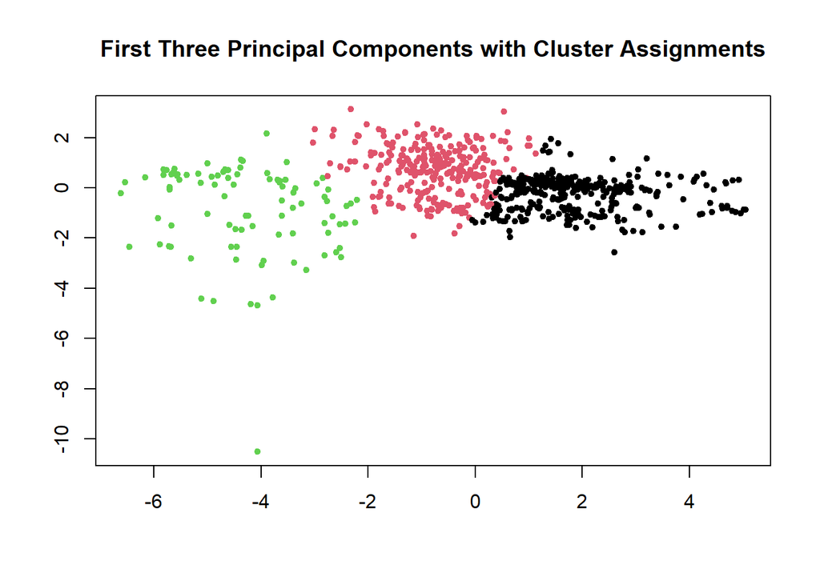

```r
# Perform PCA
pc <- prcomp(data.scaled)

# Extract the first three principal components
pc_first_three <- pc$x[, 1:3]

# Perform K-means clustering on the first three principal components
set.seed(123)  # For reproducibility
k <- 3  # Number of clusters
km_clusters <- kmeans(pc_first_three, centers = k)

# Plot the first three principal components with cluster assignments
plot(pc_first_three, col = km_clusters$cluster,
     main = "First Three Principal Components with Cluster Assignments",
     xlab = "", ylab = "", pch = 20)
```

Q: Can hierarchical clustering based on the first three principal components effectively reveal underlying patterns or groupings within the dataset, and how do the relationships between samples, as depicted in the dendrogram, reflect the distances in the reduced-dimensional space?

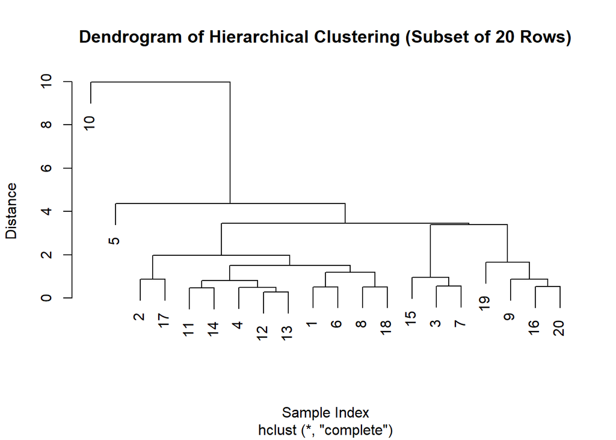

```r
# Perform PCA
pc <- prcomp(data.scaled)

# Extract the first three principal components
pc_first_three <- pc$x[, 1:3]

# Take a subset of 20 rows
data_subset <- data[1:20, ]

# Perform PCA
pca_result <- prcomp(data_subset)

# Extract the first three principal components
pc_first_three <- pca_result$x[, 1:3]

# Perform hierarchical clustering on the first three principal components
hc <- hclust(dist(pc_first_three))

# Plot the dendrogram
plot(hc, main = "Dendrogram of Hierarchical Clustering (Subset of 20 Rows)",
     xlab = "Sample Index", ylab = "Distance", sub = NULL)
```

The plot shows the first three principal components, performs hierarchical clustering on them, and plots a dendrogram showing the relationships between the samples based on their distances in the reduced-dimensional space.

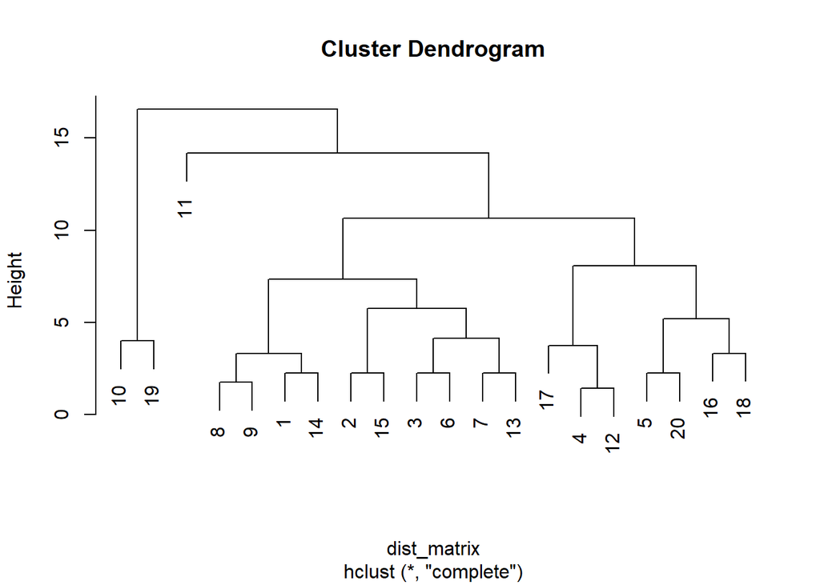

```r
library(magrittr)
library(NbClust)


# Define the file path
file_path <- "D:/Multivariate Analysis/Datasets/Body Measurements _ original_CSV.csv"

# Read the CSV file
body <- read.csv(file_path)

# Take a subset of 20 rows
body_subset <- body[1:20, c("ChestWidth", "ShoulderWidth", "Belly")]

# Calculate distance matrix
dist_matrix <- dist(body_subset)

# Hierarchical clustering
hclust_model <- hclust(dist_matrix)

# Plot the dendrogram
plot(hclust_model)
```

This dendrogram performs hierarchical clustering on body measurements data. It first reads a CSV file containing measurements, selects a subset of 20 rows with specific measurements, calculates the distance matrix between these measurements, conducts hierarchical clustering, and finally plots a dendrogram to visualize the clusters formed based on similarity between measurements.

```r
num_clusters <- 3
clusters <- cutree(hclust_model, k = num_clusters)

# Membership for each cluster
table(km_clusters$cluster)
```

```
##
##   1   2   3
## 337 281  98
```

Q: What is the degree of separation or distinctiveness among the identified clusters when analyzing the distribution of data points in the two-dimensional space formed by the first two Principal Components?

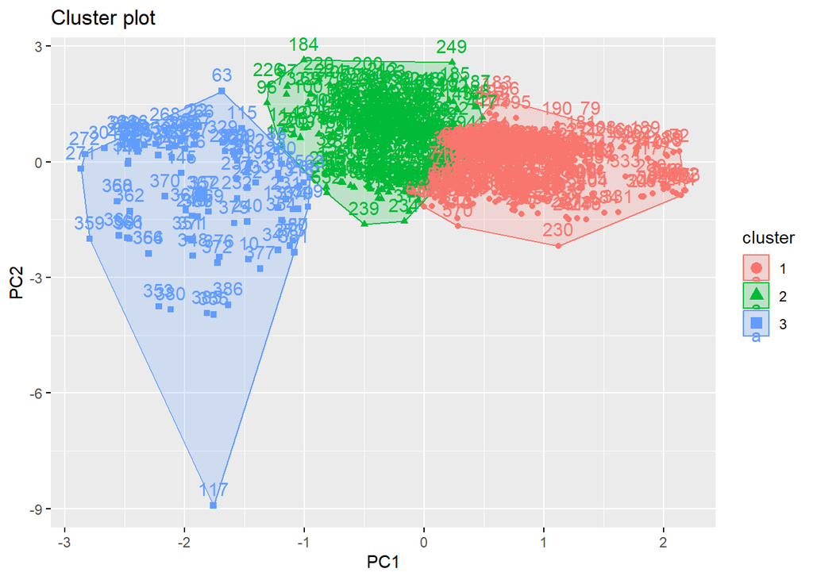

```r
# Visualize cluster and membership using first two Principal Components
fviz_cluster(list(data = pc$x[, 1:2], cluster = km_clusters$cluster))
```

This plot visualizes clustering results by plotting data points in a two-dimensional space using the first two Principal Components. Each point is colored according to its assigned cluster, showing the grouping pattern identified by the clustering algorithm. It helps understand how data points are grouped based on their features.

```r
# Non-hierarchical clustering (k-means)
num_clusters <- 2
kmeans_model <- kmeans(data, centers = num_clusters)

# Membership for each cluster
table(kmeans_model$cluster)
```

```
##
##   1   2
## 291 425
```

This represents clustering using the k-means algorithm, dividing data into two clusters. It initializes cluster centers randomly, assigning each data point to the nearest cluster. The table function counts the number of data points assigned to each cluster, providing insight into cluster membership and distribution.

Q: What is the distribution of cluster sizes obtained through k-means clustering when applied to the dataset using the first two principal components, and how does it compare to the distribution of cluster sizes obtained from clustering in the original feature space?

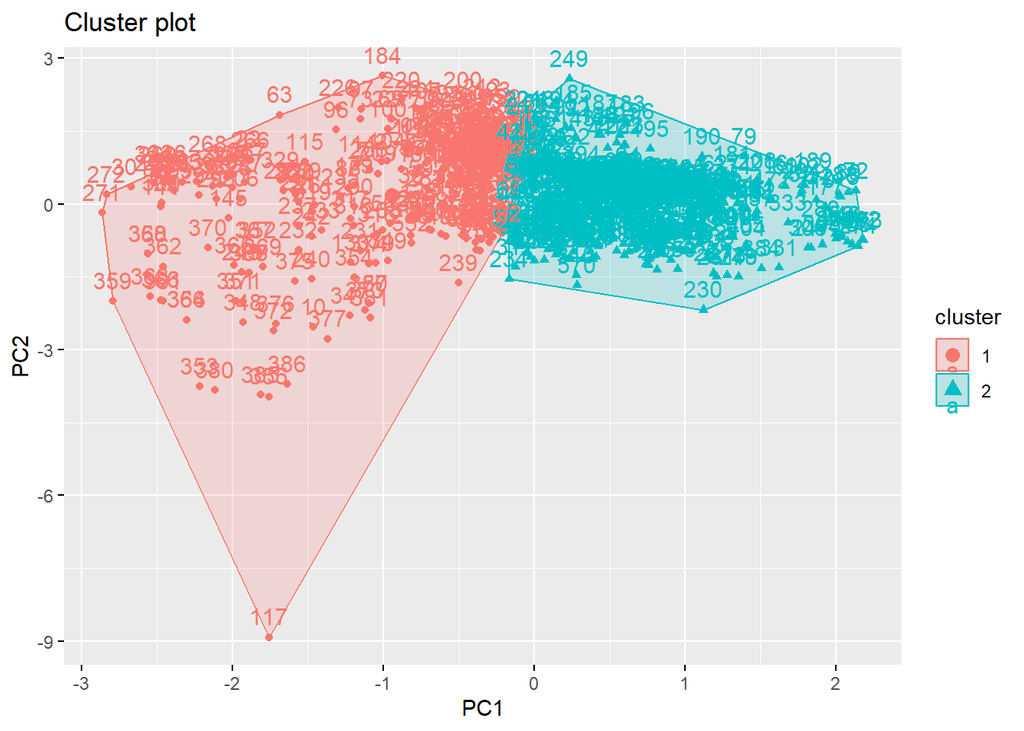

```r
# Visualize cluster and membership using first two Principal Components
fviz_cluster(list(data = pc$x[, 1:2], cluster = kmeans_model$cluster))
```

This plot visualizes clusters and their memberships using the first two principal components. It extracts these components from the data, then assigns each data point to a cluster using k-means clustering. Finally, it creates a visual representation showing how the data points are grouped based on their similarities in the first two principal components.

Q: What is the relationship between the clustering results obtained through k-means algorithm and the underlying structure of the data as revealed by Principal Component Analysis (PCA)?

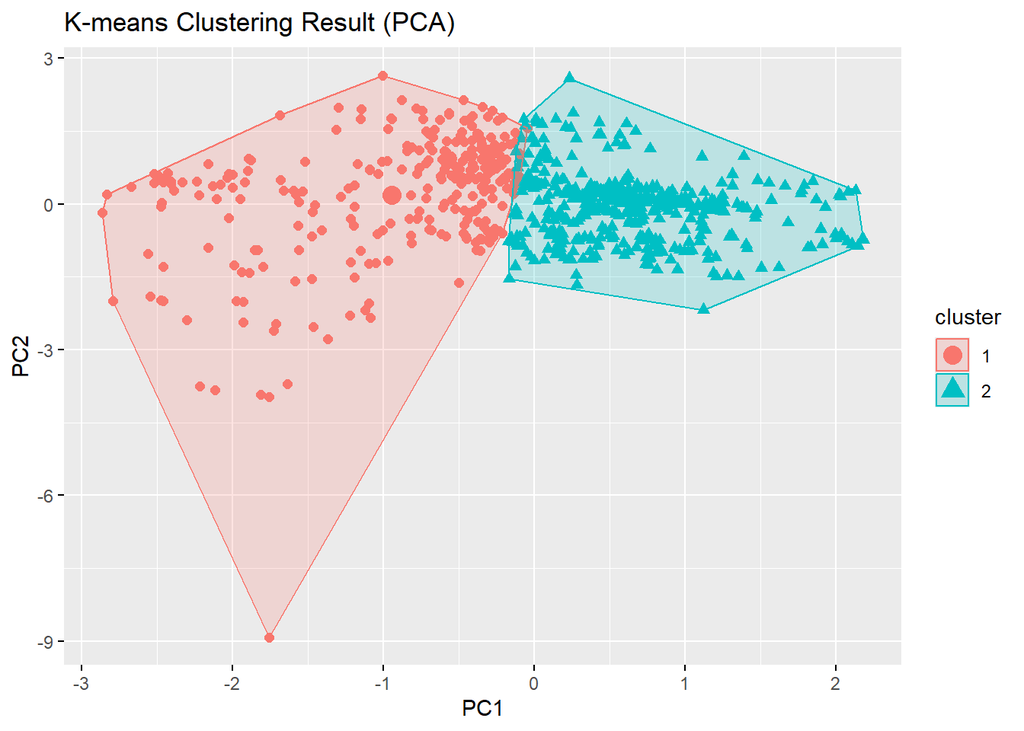

```r
# Visualize cluster and membership using first two Principal Components for k-means
pca_result <- prcomp(data, scale = TRUE)
fviz_cluster(kmeans_model, data = pca_result$x[, 1:2], geom = "point",
             pointsize = 2, fill = "white", main = "K-means Clustering Result (PCA)")
```

Q:What is the relationship between the number of clusters (k) and the average silhouette width in k-means clustering, and how does this relationship inform the determination of the optimal number of clusters for a given dataset?

```r
library(factoextra)
library(cluster)
```

```
##   cluster size ave.sil.width
## 1       1  291          0.09
## 2       2  425          0.42
```

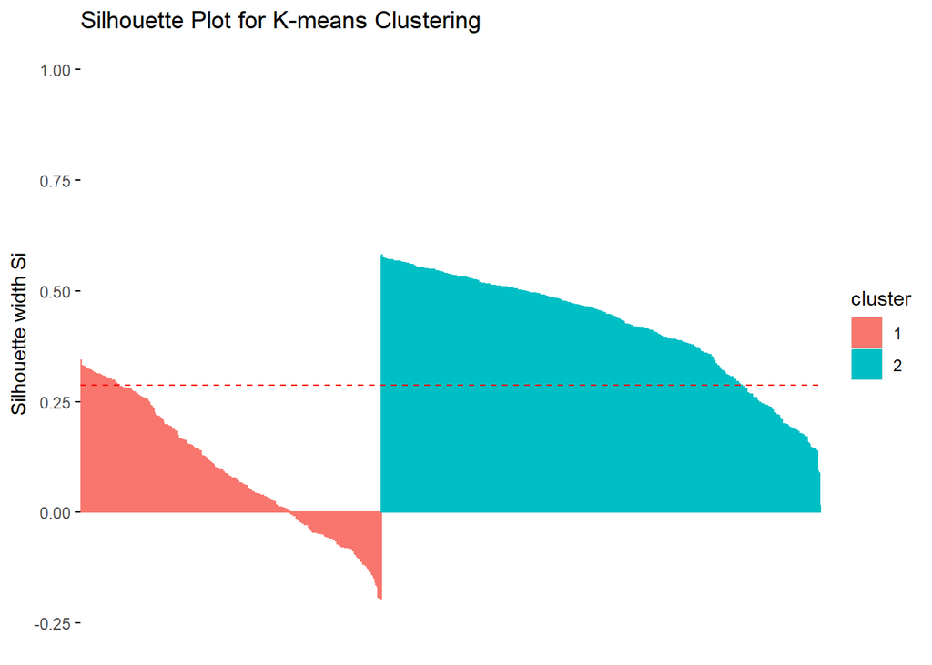

```r
# Calculate silhouette information for k-means clustering
sil <- silhouette(kmeans_model$cluster, dist(data))

# Visualize the silhouette plot for k-means clustering
fviz_silhouette(sil, main = "Silhouette Plot for K-means Clustering")
```

This plot calculates and visualizes the silhouette information for k-means clustering. Silhouette analysis helps evaluate the quality of clustering by measuring how similar an object is to its own cluster compared to other clusters. A higher silhouette width indicates better separation of clusters, while negative values suggest that points might be assigned to the wrong clusters. This plot helps in determining the optimal number of clusters for k-means clustering and assessing the overall clustering performance.

Q: Is there a significant difference in the clustering patterns based on ChestWidth and ShoulderWidth among different groups represented by distinct colors on the plot?

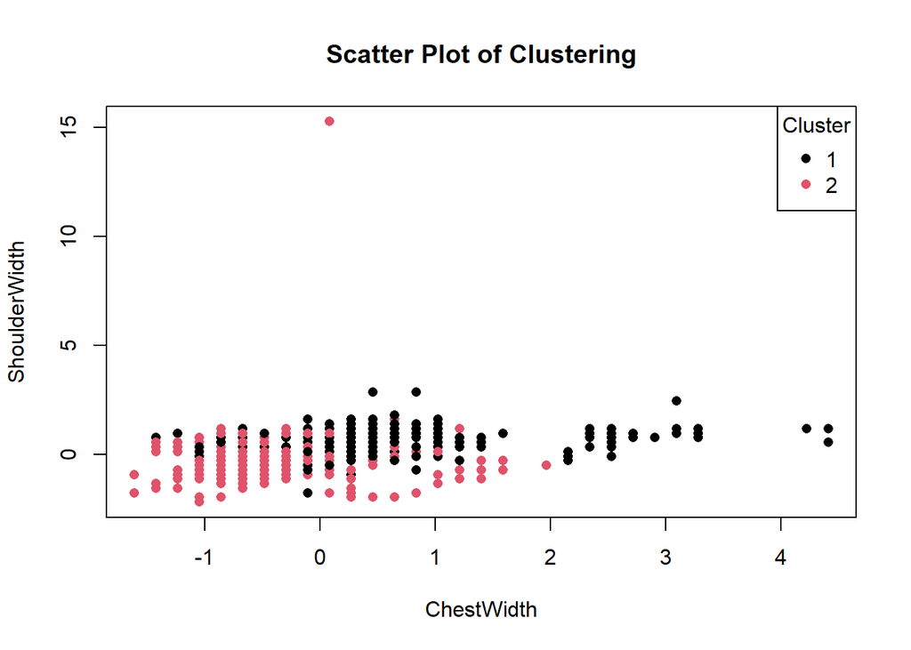

```r
# Create a data frame with cluster membership
data_clustered <- data.frame(data, Cluster = kmeans_model$cluster)  # Ensure conversion to data frame

# Scatter plot of data points colored by cluster membership
plot(data_clustered$ChestWidth, data_clustered$ShoulderWidth,
     col = data_clustered$Cluster, pch = 16,
     xlab = "ChestWidth", ylab = "ShoulderWidth",
     main = "Scatter Plot of Clustering")
legend("topright", legend = unique(data_clustered$Cluster),
       col = 1:max(data_clustered$Cluster), pch = 16, title = "Cluster")
```

Overall, this plot visualizes clusters in the data, helping us understand how data points group together based on their ChestWidth and ShoulderWidth, with each group represented by a different color on the plot.

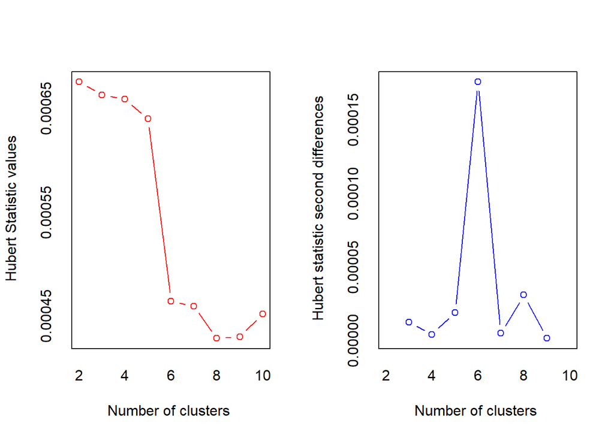

```
## *** : The Hubert index is a graphical method of determining the number of clusters.
##                 In the plot of Hubert index, we seek a significant knee that corresponds to a
##                 significant increase of the value of the measure i.e the significant peak in Hubert
##                 index second differences plot.
##
```

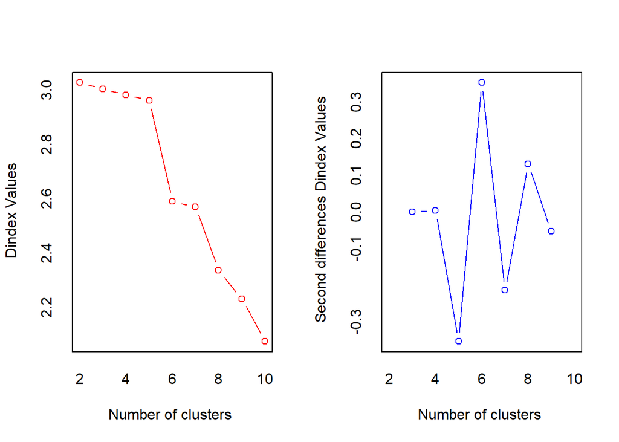

```
## *** : The D index is a graphical method of determining the number of clusters.
##                 In the plot of D index, we seek a significant knee (the significant peak in Dindex
##                 second differences plot) that corresponds to a significant increase of the value of
##                 the measure.
##
## * Among all indices:
## * 7 proposed 2 as the best number of clusters
## * 1 proposed 3 as the best number of clusters
## * 3 proposed 4 as the best number of clusters
## * 2 proposed 5 as the best number of clusters
## * 5 proposed 6 as the best number of clusters
## * 1 proposed 7 as the best number of clusters
## * 2 proposed 8 as the best number of clusters
## * 3 proposed 10 as the best number of clusters
##
##                    ***** Conclusion *****
##
## * According to the majority rule, the best number of clusters is  2
##
##
```

```r
res.nbclust <- data %>% scale() %>% NbClust(distance = "euclidean", min.nc = 2, max.nc = 10, method = "complete", index ="all")
```

This analysis uses the NbClust function. It scales the data, then determines the optimal number of clusters (min.nc to max.nc) based on various indices. It uses Euclidean distance and complete linkage method to measure dissimilarities between observations in multivariate data for clustering.